# EXPLORATORY DATA ANALYSIS

```python
import pandas as pd
import numpy as np
# for Box-Cox Transformation
from scipy import stats

# for min_max scaling
from mlxtend.preprocessing import minmax_scaling

# plotting modules
import seaborn as sns
import missingno

import matplotlib.pyplot as plt



df = pd.read_csv("store.csv")
df.head()
```

|  | BranchName | Week | DayWeek | Day | Month | Hour | Transaction_Type | Units | Amount |
| --- | --- | --- | --- | --- | --- | --- | --- | --- | --- |
| 0 | MyStore | 1 | 3 | 2 | 1 | 9 | Card | 3 | $54.00 |
| 1 | MyStore | 1 | 3 | 2 | 1 | 10 | Cash | 7 | -$17.80 |
| 2 | MyStore | 1 | 3 | 2 | 1 | 10 | Card | 7 | $41.99 |
| 3 | MyStore | 1 | 3 | 2 | 1 | 11 | Card | 20 | $412.50 |
| 4 | MyStore | 1 | 3 | 2 | 1 | 12 | Cash | 1 | -$18.00 |

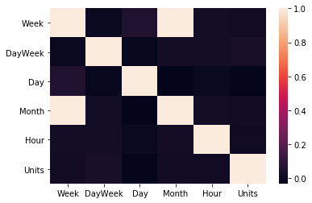

```python
sns.heatmap(df.corr())
```

First let us clean the data set ready for the analysis. As you can see there is the dolar sign infront of every Amount this will make it very hard to perform mathematical operations. As part of the cleaning, we will remove the dolar sign.

```python
df['Amount'] = df['Amount'].str.replace('$','').str.replace(',','')
df['Amount'] = pd.to_numeric(df['Amount'])
df.tail()
```

|  | BranchName | Week | DayWeek | Day | Month | Hour | Transaction_Type | Units | Amount |
| --- | --- | --- | --- | --- | --- | --- | --- | --- | --- |
| 4095 | MyStore | 53 | 1 | 31 | 12 | 13 | Card | 10 | 129.00 |
| 4096 | MyStore | 53 | 1 | 31 | 12 | 14 | Cash | 32 | -68.36 |
| 4097 | MyStore | 53 | 1 | 31 | 12 | 14 | Card | 5 | 71.00 |
| 4098 | MyStore | 53 | 1 | 31 | 12 | 15 | Cash | 66 | -359.18 |
| 4099 | MyStore | 53 | 1 | 31 | 12 | 15 | Card | 4 | 130.00 |

Another thing to note is in the Branch name variable, only one branch is seen through out the whole data frame. We therefore do not need this variable. If the data was from different stores we would have need for it. Below we drop the variable from the data frame

```python
df.drop('BranchName',axis=1, inplace=True)
df.head(10)
```

|  | Week | DayWeek | Day | Month | Hour | Transaction_Type | Units | Amount |
| --- | --- | --- | --- | --- | --- | --- | --- | --- |
| 0 | 1 | 3 | 2 | 1 | 9 | Card | 3 | 54.00 |
| 1 | 1 | 3 | 2 | 1 | 10 | Cash | 7 | -17.80 |
| 2 | 1 | 3 | 2 | 1 | 10 | Card | 7 | 41.99 |
| 3 | 1 | 3 | 2 | 1 | 11 | Card | 20 | 412.50 |
| 4 | 1 | 3 | 2 | 1 | 12 | Cash | 1 | -18.00 |
| 5 | 1 | 3 | 2 | 1 | 12 | Card | 1 | -5.00 |
| 6 | 1 | 3 | 2 | 1 | 12 | Card | 15 | 118.50 |
| 7 | 1 | 3 | 2 | 1 | 13 | Cash | 90 | -94.92 |
| 8 | 1 | 3 | 2 | 1 | 13 | Card | 28 | 423.50 |
| 9 | 1 | 3 | 2 | 1 | 14 | Cash | 34 | -95.39 |

Always check out for missing values, fortunately for this datset we have no missing values, This is not always the case and it is important to remember ways to handle missing data that we tackled in the previous task.

```python
# get the number of missing data points per column
missing_values_count = df.isnull().sum()

# look at the # of missing points in the first ten columns
missing_values_count[0:8]
```

```
Week                0
DayWeek             0
Day                 0
Month               0
Hour                0
Transaction_Type    0
Units               0
Amount              0
dtype: int64
```

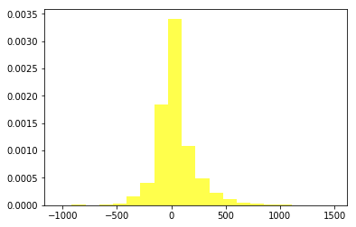

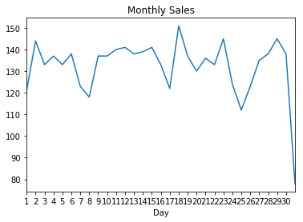

```python
plt.hist(df['Amount'], 20, density =1,facecolor="yellow", alpha=0.7)
plt.show()

test = df['Amount'].groupby(df['Day']).size()
plot_month = test.plot(title = 'Monthly Sales', xticks = (range(1,31)))
```

```python
positive = df.Amount[df['Amount'] > 0].count()
negative = df.Amount[df['Amount'] < 0].count()
print( 'positive = ', positive,'negative = ', negative)
```

```
positive =  1968 negative =  2131
```

As you can see, there are more negative values for amounts than positive. It now that you investigate from the company why they recored amounts in the negative. Can be transactions made on credit or any other cause that may inform the analysis.

```python
sales_by_card = df.groupby('Transaction_Type').size()

print(sales_by_card)
```

```
Transaction_Type
Card    2811
Cash    1289
dtype: int64
```

### Sales by Month

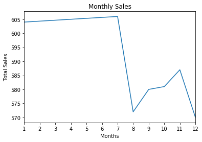

```python
sales_by_month = df.groupby('Month').size()
plot_month = sales_by_month.plot(title = 'Monthly Sales', xticks = (1,2,3,4,5,6,7,8,9,10,11,12))
plot_month.set_xlabel('Months')
plot_month.set_ylabel('Total Sales')
```

### Sales by Day

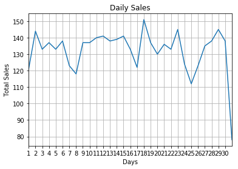

```python
sales_by_month = df.groupby('Day').size()
plot_month = sales_by_month.plot(title = 'Daily Sales', xticks = (range(1,31)), grid=True)
plot_month.set_xlabel('Days')
plot_month.set_ylabel('Total Sales')
```

Sales were fluctuating throughout the month but surprisingly there seems to be a significant drop at the end of the month. This is another point to investigate. Common sense dictates that the sales should increase at the end of the month but this happens in the contrary. Finding the reason behind it can be very interesting. Do you have any assumptions?

### Sale by Hour

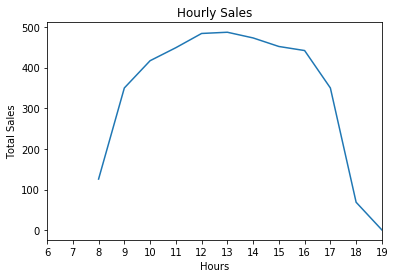

```python
sales_by_month = df.groupby('Hour').size()
plot_month = sales_by_month.plot(title = 'Hourly Sales', xticks = (range(6,20)))
plot_month.set_xlabel('Hours')
plot_month.set_ylabel('Total Sales')
```

The sales seem to take a bell shape. The sales are highest from 11:00AM to 4:00PM. More customers visit in after noon than closing and opening hours. This can inform the administration on how to do the staffing and all other decisions.

Great, now that we have some back ground in storytelling in EDA now let us begin from the top.

### Exploratory Data Analysis on the Balance data set

We have handled the balance data set before but we only handled missing values. We will now try and do alot more.

According to our rubric, the first step is

#### 1. What question are you trying to solve (or prove wrong)?

For this data set what we can build is a model that, according to the present variables, can predict the balance of future clients.

#### 2. What kind of data do you have?

Is your data numerical, categorical or something else? How do you deal with each kind?

As we can observe, we have

Balance - [double][Continuous] The balance in the clients account

Income - [double][Continuous] The clients income.

Limit - [integer][Continuous] This is the credit card limit

Rating - [Double][Continuous] This is the Rating given to a client.

Cards - [Integer][Categorical] This is the number of cards the client has

Age - [Integer][Categorical] This is the age of the client

Education - [Integer] [Categorical]This is the highest level of education attained by the client.

Gender - [String] [Categorical] Male or Female

Student - [String] [Categorical] Yes - the client is a student No - Client is not a student

Married - [String] [Categorical] Yes - Client is married No - client is unmarried.

Ethnicity - [String] [Categorical] client can be Caucasion,Asian or African

```python
balance = pd.read_table('balance.txt', delim_whitespace=True)
balance.head(10)
```

|  | Balance | Income | Limit | Rating | Cards | Age | Education | Gender | Student | Married | Ethnicity |
| --- | --- | --- | --- | --- | --- | --- | --- | --- | --- | --- | --- |
| 0 | 12.240798 | 14.891 | 3606 | 283.0 | 2.0 | NaN | 11.0 | Male | No | Yes | Caucasian |
| 1 | 23.283334 | NaN | 6645 | 483.0 | 3.0 | 82.0 | 15.0 | Female | NaN | Yes | Asian |
| 2 | 22.530409 | 104.593 | 7075 | NaN | 4.0 | 71.0 | 11.0 | Male | No | No | Asian |
| 3 | 27.652811 | 148.924 | 9504 | 681.0 | 3.0 | 36.0 | 11.0 | NaN | No | No | Asian |
| 4 | 16.893978 | 55.882 | 4897 | 357.0 | 2.0 | 68.0 | 16.0 | Male | No | Yes | Caucasian |
| 5 | 22.486178 | 80.180 | 8047 | 569.0 | 4.0 | 77.0 | 10.0 | Male | No | No | Caucasian |
| 6 | 10.574516 | 20.996 | 3388 | 259.0 | 2.0 | 37.0 | 12.0 | Female | No | No | African American |
| 7 | 14.576204 | 71.408 | 7114 | 512.0 | 2.0 | 87.0 | 9.0 | Male | No | No | Asian |
| 8 | 7.938090 | 15.125 | 3300 | 266.0 | 5.0 | 66.0 | 13.0 | Female | No | No | Caucasian |
| 9 | 17.756965 | 71.061 | 6819 | 491.0 | 3.0 | 41.0 | 19.0 | Female | Yes | Yes | African American |

```python
f= [True, False, True]
print([f for i in f if f == True])
```

```
[]
```

#### 3. What’s missing from the data and how do you deal with?

What missing values are there? Where are the holes in our data?

These are rows which are missing a value or have NaN instead of something like the rest of the column.

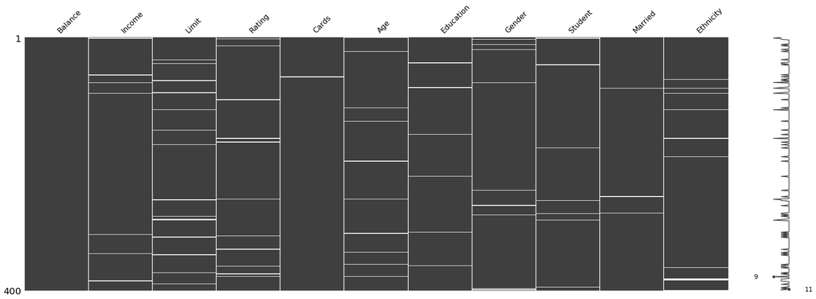

```python
# Plot graphic of missing values
missingno.matrix(balance, figsize = (30,10))
```

We can now be able to visualize where the data is missing and be able to strategize. We handled missing data in this data set in the previous task so if you need any refreshers refer to the previous task.